# Tugas Praktikum 1 MPDW

Kaylila Kireinahana

2023-12-19

Library

```r
library("forecast")
```

```r
library("graphics")
library("TTR")
library("TSA")
library(rio)
data_mpdw <- import("https://raw.githubusercontent.com/reiflection/MPDW/main/Data/Cerial%20Prices.csv")
periode <- rep(1:360)
data_mpdw <- cbind(data_mpdw, periode)
```

Eksplorasi Data

```r
View(data_mpdw)
str(data_mpdw)
```

```
## 'data.frame':    360 obs. of  10 variables:
##  $ Year                : int  1992 1992 1992 1992 1992 1992 1992 1992 1992 1992 ...
##  $ Month               : chr  "Feb" "Mar" "Apr" "May" ...
##  $ Price_wheat_ton     : num  170 161 153 140 140 ...
##  $ Price_rice_ton      : num  278 277 278 274 269 ...
##  $ Price_corn_ton      : num  114 117 109 110 111 ...
##  $ Inflation_rate      : num  89.6 89.6 89.6 89.6 89.6 ...
##  $ Price_wheat_ton_infl: num  323 306 290 265 266 ...
##  $ Price_rice_ton_infl : num  528 526 527 519 510 ...
##  $ Price_corn_ton_infl : num  215 222 206 208 210 ...
##  $ periode             : int  1 2 3 4 5 6 7 8 9 10 ...
```

```r
dim(data_mpdw)
```

```
## [1] 360  10
```

```r
summary(data_mpdw$Price_rice_ton)
```

```
##    Min. 1st Qu.  Median    Mean 3rd Qu.    Max.
##   163.8   261.6   344.7   364.1   444.2   907.0
```

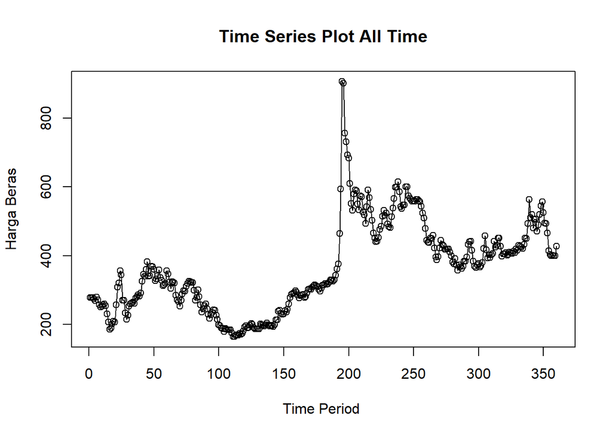

```r
rice.all.ts <- ts(data_mpdw$Price_rice_ton)
ts.plot(rice.all.ts, xlab="Time Period ", ylab="Harga Beras",
        main = "Time Series Plot All Time")
points(rice.all.ts)
```

```r
rice.ts <- ts(data_mpdw$Price_rice_ton[240:360])
```

Plot Deret Waktu

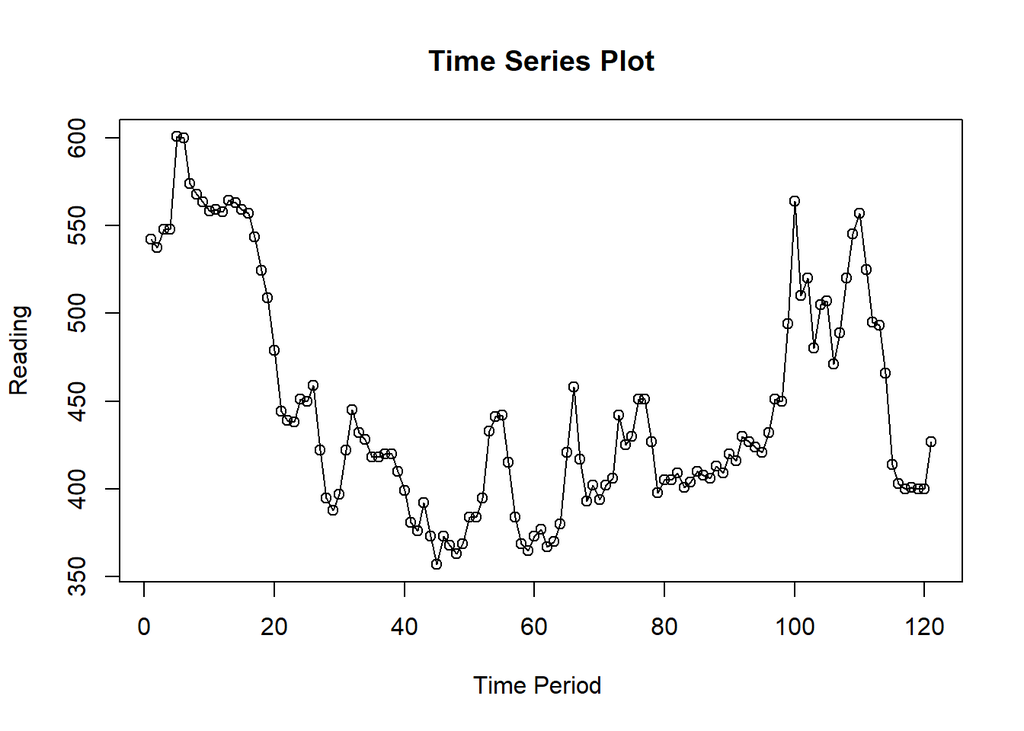

```r
ts.plot(rice.ts, xlab="Time Period ", ylab="Reading",
        main = "Time Series Plot")
points(rice.ts)
```

Grafik deret waktu menunjukkan pola yang tidak konstan atau tren.

Pembagian data latih dan uji sebanyak 80% dan 20%

```r
rma_train <- data_mpdw[240:336,]
rma_test <- data_mpdw[336:360,]
rma_train.ts <- ts(rma_train$Price_rice_ton)
rma_test.ts <- ts(rma_test$Price_rice_ton)
```

Eksplorasi data latih dan uji

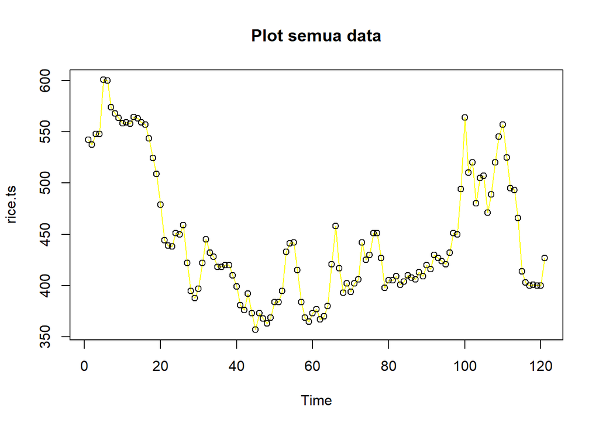

```r
#eksplorasi keseluruhan data
plot(rice.ts, col="yellow",main="Plot semua data")
points(rice.ts)
```

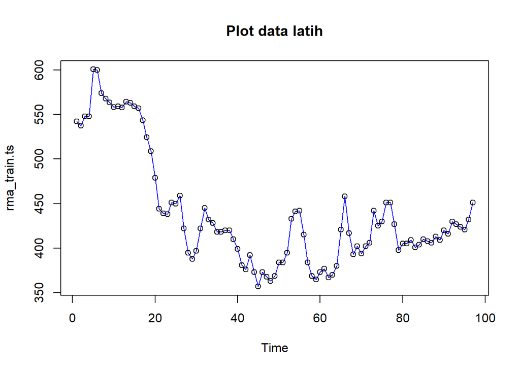

```r
#eksplorasi data latih
plot(rma_train.ts, col="blue",main="Plot data latih")
points(rma_train.ts)
```

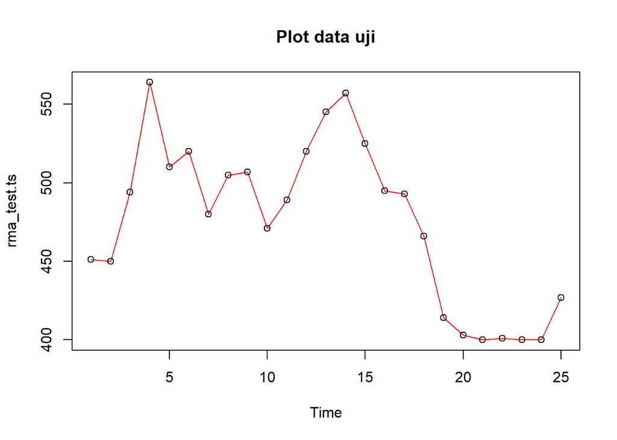

```r
#eksplorasi data uji
plot(rma_test.ts, col="red",main="Plot data uji")
points(rma_test.ts)
```

Eksplorasi Data Gabungan

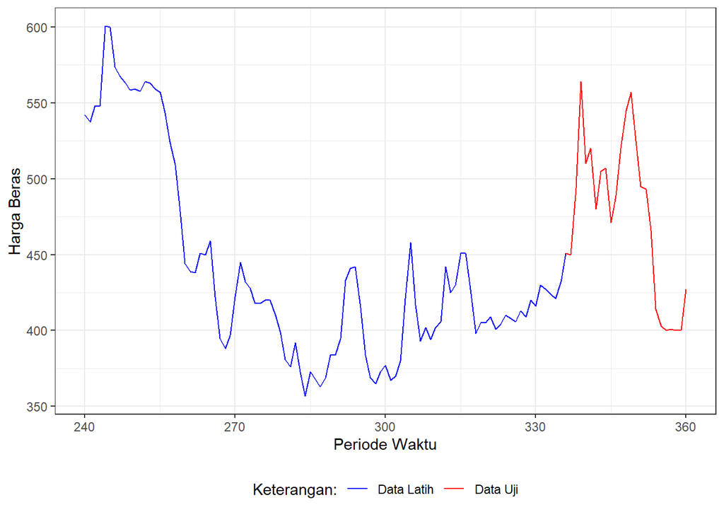

```r
library(ggplot2)
ggplot() +
  geom_line(data = rma_train, aes(x = periode, y = Price_rice_ton, col = "Data Latih")) +
  geom_line(data = rma_test, aes(x =periode, y = Price_rice_ton, col = "Data Uji")) +
  labs(x = "Periode Waktu", y = "Harga Beras", color = "Legend") +
  scale_colour_manual(name="Keterangan:", breaks = c("Data Latih", "Data Uji"),
                      values = c("blue", "red")) +
  theme_bw() + theme(legend.position = "bottom",
                     plot.caption = element_text(hjust=0.5, size=12))
```

## Double Moving Average

```r
rice.sma.dma<-SMA(rma_train.ts, n=11)
rdma <- SMA(rice.sma.dma, n = 11)
At <- 2*rice.sma.dma - rdma
Bt <- 2/(11-1)*(rice.sma.dma - rdma)
rice.dma<- At+Bt
rice.ramal.dma<- c(NA, rice.dma)

t = 1:25
f = c()

for (i in t) {
  f[i] = At[length(At)] + Bt[length(Bt)]*(i)
}

data.gab2 <- cbind(aktual = c(rma_train.ts, rep(NA,25)), pemulusan1 = c(rice.sma.dma, rep(NA,25)), pemulusan2 = c(rice.dma, rep(NA,25)),At = c(At, rep(NA,25)), Bt = c(Bt,rep(NA,25)),ramalan = c(rice.ramal.dma, f[-1]))
data.gab2
```

```
##        aktual pemulusan1 pemulusan2       At           Bt  ramalan
##   [1,] 542.00         NA         NA       NA           NA       NA
##   [2,] 537.50         NA         NA       NA           NA       NA
##   [3,] 548.00         NA         NA       NA           NA       NA
##   [4,] 547.75         NA         NA       NA           NA       NA
##   [5,] 600.50         NA         NA       NA           NA       NA
##   [6,] 600.00         NA         NA       NA           NA       NA
##   [7,] 573.75         NA         NA       NA           NA       NA
##   [8,] 567.75         NA         NA       NA           NA       NA
##   [9,] 563.25         NA         NA       NA           NA       NA
##  [10,] 558.25         NA         NA       NA           NA       NA
##  [11,] 559.25   563.4545         NA       NA           NA       NA
##  [12,] 557.80   564.8909         NA       NA           NA       NA
##  [13,] 564.20   567.3182         NA       NA           NA       NA
##  [14,] 563.00   568.6818         NA       NA           NA       NA
```

[output cut: 108 more lines]

Visualisasi hasil pemulusan DMA untuk 80% data

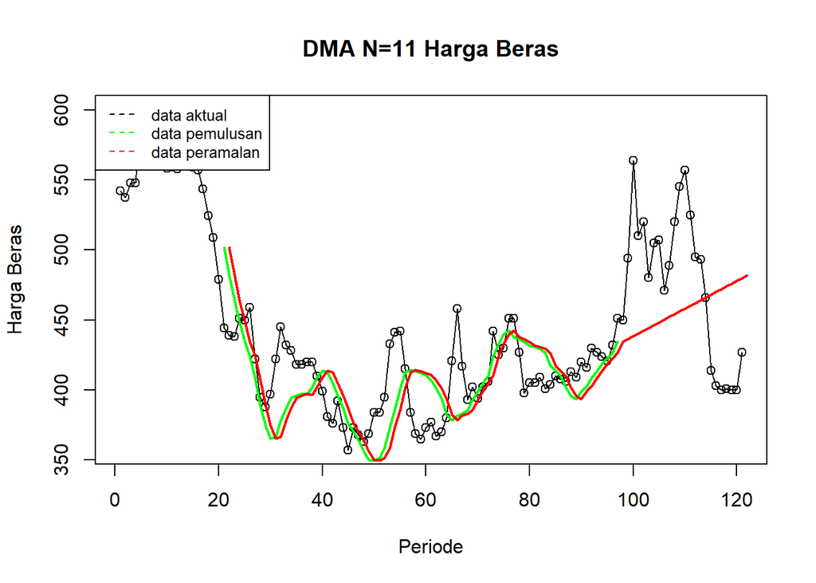

```r
ts.plot(rice.ts, xlab="Periode", ylab="Harga Beras", main= "DMA N=11 Harga Beras")
points(rice.ts)
lines(data.gab2[,3],col="green",lwd=2)
lines(data.gab2[,6],col="red",lwd=2)
legend("topleft",c("data aktual","data pemulusan","data peramalan"), lty=8, col=c("black","green","red"), cex=0.8)
```

```r
#Menghitung nilai keakuratan data latih
rdma_train.error = rma_train.ts-rice.ramal.dma[1:length(rma_train.ts)]
rdma_train.sse = sum(rdma_train.error[22:length(rma_train.ts)]^2)
rdma_train.mse = mean(rdma_train.error[22:length(rma_train.ts)]^2)
rdma_train.mape = mean(abs((rdma_train.error[22:length(rma_train.ts)]/rma_train.ts[22:length(rma_train.ts)])*100))

akurasi_train.dma <- matrix(c(rdma_train.sse, rdma_train.mse, rdma_train.mape))
row.names(akurasi_train.dma)<- c("SSE", "MSE", "MAPE")
colnames(akurasi_train.dma) <- c("Akurasi m = 11")
akurasi_train.dma
```

```
##      Akurasi m = 11
## SSE    74774.018247
## MSE      983.868661
## MAPE       6.014992
```

nilai MAPE untuk pengujian data latih dibawah 10% yang menandakan sudah cukup baik.

```r
#Menghitung nilai keakuratan data latih
rdma_test.error = rma_test.ts-data.gab2[98:122,6]
rdma_test.sse = sum(rdma_test.error^2)
rdma_test.mse = mean(rdma_test.error^2)
rdma_test.mape = mean(abs((rdma_test.error/rma_test.ts*100)))

akurasi_test.dma <- matrix(c(rdma_test.sse, rdma_test.mse, rdma_test.mape))
row.names(akurasi_test.dma)<- c("SSE", "MSE", "MAPE")
colnames(akurasi_test.dma) <- c("Akurasi m = 10")
akurasi_test.dma
```

```
##      Akurasi m = 10
## SSE     99318.75353
## MSE      3972.75014
## MAPE       11.92014
```

## Double Exponetial Smoothing

Membagi data untuk DES

```r
res_train<-data_mpdw[240:336,]
res_test<-data_mpdw[336:360,]
res_train.ts <- ts(res_train$Price_rice_ton)
res_test.ts <- ts(res_test$Price_rice_ton)
```

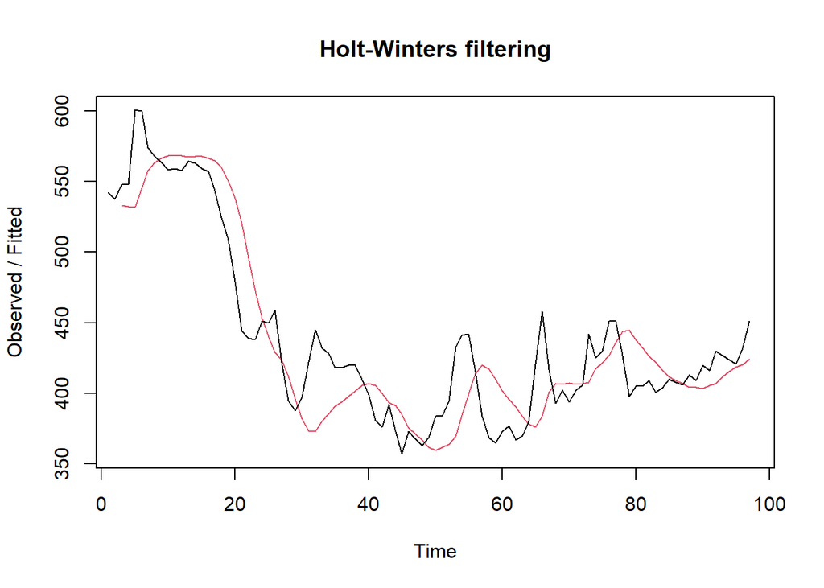

```r
#Lamda=0.2 dan gamma=0.2
des.1<- HoltWinters(res_train.ts, gamma = FALSE, beta = 0.2, alpha = 0.2)
plot(des.1)
```

```r
#ramalan
ramalandes1<- forecast(des.1, h=25)
ramalandes1
```

```
##     Point Forecast    Lo 80    Hi 80    Lo 95    Hi 95
##  98       432.5934 395.1529 470.0339 375.3330 489.8537
##  99       435.4089 396.9052 473.9126 376.5226 494.2952
## 100       438.2244 398.3191 478.1298 377.1945 499.2544
## 101       441.0400 399.3749 482.7051 377.3187 504.7612
## 102       443.8555 400.0645 487.6465 376.8830 510.8281
## 103       446.6711 400.3900 492.9521 375.8903 517.4519
## 104       449.4866 400.3610 498.6122 374.3555 524.6177
## 105       452.3021 399.9925 504.6118 372.3014 532.3028
## 106       455.1177 399.3024 510.9329 369.7556 540.4797
## 107       457.9332 398.3099 517.5566 366.7472 549.1193
## 108       460.7487 397.0338 524.4637 363.3052 558.1923
## 109       463.5643 395.4925 531.6360 359.4575 567.6711
## 110       466.3798 393.7028 539.0569 355.2299 577.5298
## 111       469.1954 391.6799 546.7108 350.6457 587.7450
## 112       472.0109 389.4378 554.5840 345.7262 598.2956
## 113       474.8264 386.9887 562.6641 340.4902 609.1626
## 114       477.6420 384.3437 570.9402 334.9546 620.3294
## 115       480.4575 381.5125 579.4025 329.1342 631.7809
## 116       483.2730 378.5038 588.0423 323.0423 643.5038
## 117       486.0886 375.3254 596.8518 316.6909 655.4863
## 118       488.9041 371.9842 605.8241 310.0905 667.7178
## 119       491.7197 368.4863 614.9530 303.2505 680.1888
## 120       494.5352 364.8375 624.2329 296.1796 692.8908
## 121       497.3507 361.0426 633.6589 288.8854 705.8161
## 122       500.1663 357.1063 643.2263 281.3749 718.9577
```

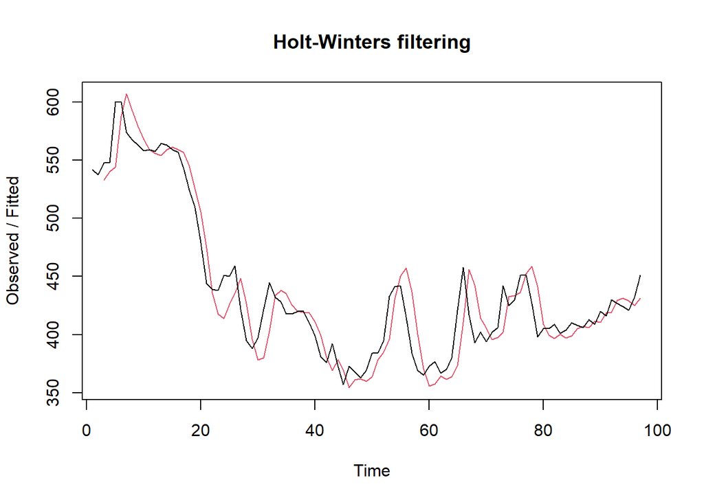

```r
#Lamda=0.6 dan gamma=0.3
des.2<- HoltWinters(res_train.ts, gamma = FALSE, beta = 0.3, alpha = 0.6)
plot(des.2)
```

```r
#ramalan
ramalandes2<- forecast(des.2, h=25)
ramalandes2
```

```
##     Point Forecast    Lo 80    Hi 80       Lo 95     Hi 95
##  98       448.5505 421.2425 475.8585 406.7865382  490.3145
##  99       454.0673 419.4346 488.7001 401.1011338  507.0336
## 100       459.5842 416.1481 503.0202 393.1544957  526.0139
## 101       465.1010 411.6610 518.5410 383.3715478  546.8305
## 102       470.6178 406.1571 535.0786 372.0336004  569.2021
## 103       476.1347 399.7601 552.5092 359.3298284  592.9395
## 104       481.6515 392.5571 570.7459 345.3933360  617.9096
## 105       487.1683 384.6123 589.7243 330.3224593  644.0142
## 106       492.6851 375.9755 609.3948 314.1930962  671.1772
## 107       498.2020 366.6862 629.7177 297.0660101  699.3379
## 108       503.7188 356.7774 650.6602 278.9913184  728.4463
## 109       509.2356 346.2766 672.1946 260.0113620  758.4599
## 110       514.7524 335.2078 694.2971 240.1626118  789.3423
## 111       520.2693 323.5918 716.9468 219.4769795  821.0616
## 112       525.7861 311.4470 740.1252 197.9827493  853.5895
## 113       531.3029 298.7901 763.8157 175.7052584  886.9006
## 114       536.8198 285.6360 788.0035 152.6674074  920.9721
## 115       542.3366 271.9984 812.6747 128.8900508  955.7831
## 116       547.8534 257.8898 837.8170 104.3923028  991.3145
## 117       553.3702 243.3216 863.4189  79.1917803 1027.5487
## 118       558.8871 228.3046 889.4695  53.3047988 1064.4693
## 119       564.4039 212.8486 915.9591  26.7465338 1102.0613
## 120       569.9207 196.9630 942.8784  -0.4688468 1140.3103
## 121       575.4375 180.6564 970.2187 -28.3280707 1179.2032
## 122       580.9544 163.9370 997.9718 -56.8186667 1218.7274
```

Pembandingan data latih dan uji melalui visualisasi

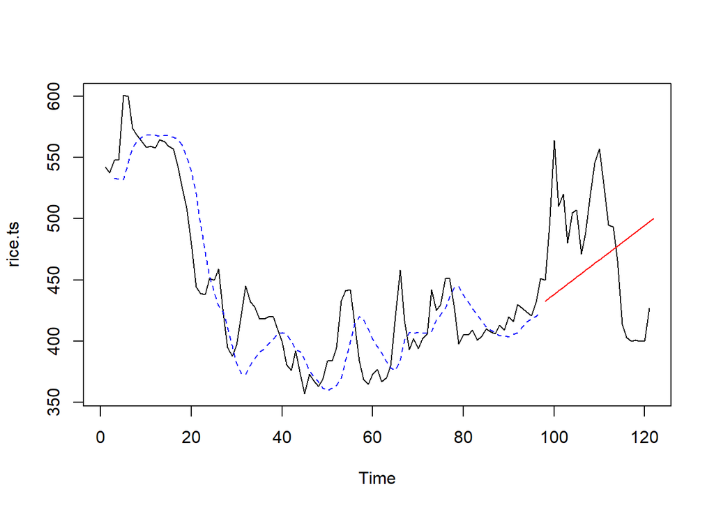

```r
plot(rice.ts)
lines(des.1$fitted[,1], lty=2, col="blue")
lines(ramalandes1$mean, col="red")
```

```r
#Lamda dan gamma optimum
des.opt<- HoltWinters(res_train.ts, gamma = FALSE)
des.opt
```

```
## Holt-Winters exponential smoothing with trend and without seasonal component.
##
## Call:
## HoltWinters(x = res_train.ts, gamma = FALSE)
##
## Smoothing parameters:
##  alpha: 1
##  beta : 0.02197316
##  gamma: FALSE
##
## Coefficients:
##          [,1]
## a 451.0000000
## b  -0.1833233
```

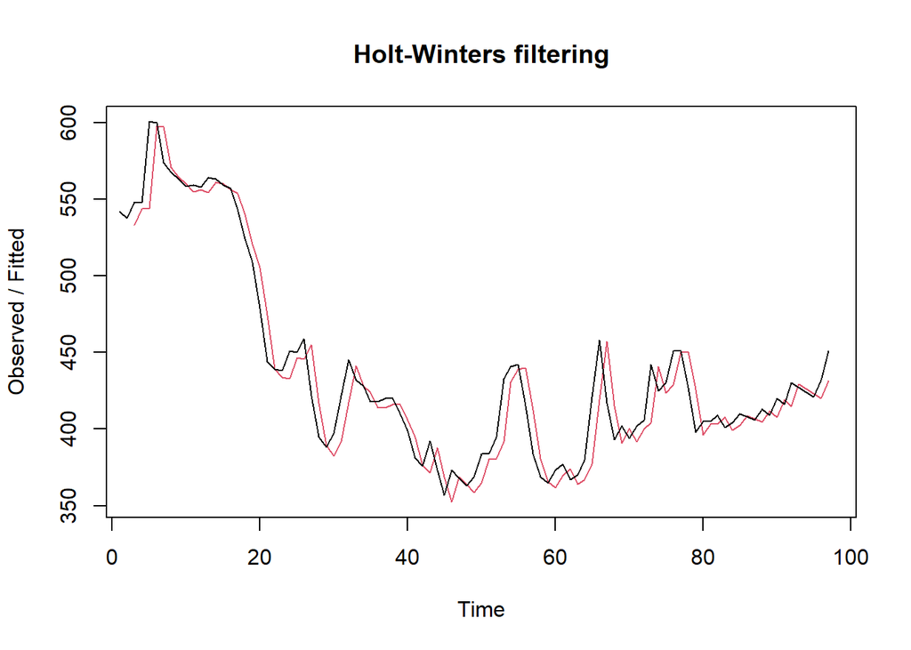

```r
plot(des.opt)
```

```r
#ramalan
ramalandesopt<- forecast(des.opt, h=25)
ramalandesopt
```

```
##     Point Forecast    Lo 80    Hi 80    Lo 95    Hi 95
##  98       450.8167 429.2485 472.3848 417.8310 483.8023
##  99       450.6334 419.7945 481.4723 403.4693 497.7974
## 100       450.4500 412.2662 488.6339 392.0529 508.8472
## 101       450.2667 405.6961 494.8374 382.1018 518.4316
## 102       450.0834 399.7138 500.4530 373.0498 527.1170
## 103       449.9001 394.1317 505.6684 364.6097 535.1904
## 104       449.7167 388.8395 510.5940 356.6130 542.8205
## 105       449.5334 383.7662 515.3007 348.9511 550.1158
## 106       449.3501 378.8629 519.8372 341.5493 557.1509
## 107       449.1668 374.0948 524.2388 334.3541 563.9795
## 108       448.9834 369.4355 528.5314 327.3253 570.6416
## 109       448.8001 364.8649 532.7353 320.4323 577.1679
## 110       448.6168 360.3674 536.8662 313.6509 583.5827
## 111       448.4335 355.9301 540.9368 306.9618 589.9051
## 112       448.2502 351.5430 544.9573 300.3493 596.1510
## 113       448.0668 347.1974 548.9363 293.8003 602.3333
## 114       447.8835 342.8863 552.8807 287.3041 608.4629
## 115       447.7002 338.6037 556.7967 280.8515 614.5489
## 116       447.5169 334.3445 560.6892 274.4347 620.5990
## 117       447.3335 330.1044 564.5626 268.0471 626.6200
## 118       447.1502 325.8796 568.4208 261.6829 632.6176
## 119       446.9669 321.6669 572.2669 255.3370 638.5967
## 120       446.7836 317.4633 576.1038 249.0053 644.5619
## 121       446.6002 313.2663 579.9341 242.6836 650.5168
## 122       446.4169 309.0739 583.7600 236.3688 656.4650
```

```r
#Akurasi Data Training
ssedes.train1<-des.1$SSE
msedes.train1<-ssedes.train1/length(res_train.ts)
sisaandes1<-ramalandes1$residuals
head(sisaandes1)
```

```
## Time Series:
## Start = 1
## End = 6
## Frequency = 1
## [1]       NA       NA 15.00000 15.65000 68.54400 54.86744
```

```r
mapedes.train1 <- sum(abs(sisaandes1[3:length(res_train.ts)]/res_train.ts[3:length(res_train.ts)])
                      *100)/length(res_train.ts)

akurasides.1 <- matrix(c(ssedes.train1,msedes.train1,mapedes.train1))
row.names(akurasides.1)<- c("SSE", "MSE", "MAPE")
colnames(akurasides.1) <- c("Akurasi lamda=0.2 dan gamma=0.2")
akurasides.1
```

```
##      Akurasi lamda=0.2 dan gamma=0.2
## SSE                     80582.545956
## MSE                       830.747896
## MAPE                        4.985057
```

```r
ssedes.train2<-des.2$SSE
msedes.train2<-ssedes.train2/length(res_train.ts)
sisaandes2<-ramalandes2$residuals
head(sisaandes2)
```

```
## Time Series:
## Start = 1
## End = 6
## Frequency = 1
## [1]       NA       NA 15.00000  7.55000 56.21100 12.30742
```

```r
mapedes.train2 <- sum(abs(sisaandes2[3:length(res_train.ts)]/res_train.ts[3:length(res_train.ts)])
                      *100)/length(res_train.ts)

akurasides.2 <- matrix(c(ssedes.train2,msedes.train2,mapedes.train2))
row.names(akurasides.2)<- c("SSE", "MSE", "MAPE")
colnames(akurasides.2) <- c("Akurasi lamda=0.6 dan gamma=0.3")
akurasides.2
```

```
##      Akurasi lamda=0.6 dan gamma=0.3
## SSE                     42713.682110
## MSE                       440.347238
## MAPE                        3.609988
```

Nilai MAPE dengan lamda = 0.6 dan gamma = 0.3 lebih kecil dibandingkan nilai MAPE pada lamda = 0.2 dan gamma = 0.2 sehingga akurasi tersebut lebih baik.

```r
#Akurasi Data Testing
selisihdes1<-ramalandes1$mean-res_test$Price_rice_ton
selisihdes1
```

```
## Time Series:
## Start = 98
## End = 122
## Frequency = 1
##  [1]  -18.40663  -14.59109  -55.77555 -122.96001  -66.14448  -73.32894
##  [7]  -30.51340  -52.69786  -51.88233  -13.06679  -28.25125  -56.43571
## [13]  -78.62018  -87.80464  -52.98910  -20.17356  -15.35803   14.45751
## [19]   69.27305   83.08859   88.90412   90.71966   94.53520   97.35074
## [25]   73.16627
```

```r
SSEtestingdes1<-sum(selisihdes1^2)
MSEtestingdes1<-SSEtestingdes1/length(res_test$Price_rice_ton)
MAPEtestingdes1<-sum(abs(selisihdes1/res_test$Price_rice_ton)*100)/length(res_test$Price_rice_ton)

selisihdes2<-ramalandes2$mean-res_test$Price_rice_ton
selisihdes2
```

```
## Time Series:
## Start = 98
## End = 122
## Frequency = 1
##  [1]  -2.4494812   4.0673461 -34.4158265 -98.8989992 -39.3821718 -43.8653445
##  [7]   1.6514829 -17.8316898 -14.3148624  27.2019649  14.7187923 -10.7643804
## [13] -30.2475530 -36.7307257   0.7861017  36.3029290  43.8197564  76.3365837
## [19] 133.8534111 150.3702384 158.8870658 163.4038931 169.9207205 175.4375478
## [25] 153.9543752
```

```r
SSEtestingdes2<-sum(selisihdes2^2)
MSEtestingdes2<-SSEtestingdes2/length(res_test$Price_rice_ton)
MAPEtestingdes2<-sum(abs(selisihdes2/res_test$Price_rice_ton)*100)/length(res_test$Price_rice_ton)

selisihdesopt<-ramalandesopt$mean-res_test$Price_rice_ton
selisihdesopt
```

```
## Time Series:
## Start = 98
## End = 122
## Frequency = 1
##  [1]   -0.1833233    0.6333534  -43.5499699 -113.7332932  -59.9166165
##  [6]  -70.0999398  -30.2832631  -55.4665864  -57.6499096  -21.8332329
## [11]  -40.0165562  -71.1998795  -96.3832028 -108.5665261  -76.7498494
## [16]  -46.9331727  -45.1164960  -18.2998193   33.5168574   44.3335341
## [21]   47.1502108   45.9668875   46.7835642   46.6002409   19.4169176
```

```r
SSEtestingdesopt<-sum(selisihdesopt^2)
MSEtestingdesopt<-SSEtestingdesopt/length(res_test$Price_rice_ton)
MAPEtestingdesopt<-sum(abs(selisihdesopt/res_test$Price_rice_ton)*100)/length(res_test$Price_rice_ton)

akurasitestingdes <-
  matrix(c(SSEtestingdes1,MSEtestingdes1,MAPEtestingdes1,SSEtestingdes2,MSEtestingdes2,
           MAPEtestingdes2,SSEtestingdesopt,MSEtestingdesopt,MAPEtestingdesopt),
         nrow=3,ncol=3)
row.names(akurasitestingdes)<- c("SSE", "MSE", "MAPE")
colnames(akurasitestingdes) <- c("des ske1","des ske2","des opt")
akurasitestingdes
```

```
##          des ske1     des ske2     des opt
## SSE  108242.11452 203218.43838 81503.16327
## MSE    4329.68458   8128.73754  3260.12653
## MAPE     12.47195     15.08272    10.16648
```

Metode DES dengan parameter optimum menghasilkan nilai MAPE yang paling kecil sehingga akurasi tersebut lebih baik dibandingkan yang lainnya.